# Corona Activity 1

### Data

The file *china-blood-covid-19.csv* contains data from the research paper. Variables in the file are:

- `city`: either Wuhan or Shenzhen;
- `group`: one of Control, or the name of a hospital;
- `diagnosis`: one of Normal (for Control) or COVID-19 (for the hospitals);
- `blood`: the blood type, one of A, B, AB, or O;
- `count`: the number of individuals in the group

```r
cbc19 = read_csv("china-blood-covid-19.csv")
```

### Problems

1. Using `tidyverse` tools, create a 2 by 4 table for the controls with one row for each city, one column for each blood type, and values which are the percentage of individuals with each blood type within each city (so the rows sum to 100%). Round percentages to whole numbers.

```r
p_1 = cbc19%>%
  select(city, blood, count, group)%>%
  filter(group=="Control")%>%
  group_by(city)%>%
  mutate(n=sum(count))%>%
  ungroup()%>%
  group_by(city, blood)%>%
  mutate(nBlood = sum(count),
         pctBlood = round((nBlood/n)*100))%>%
  ungroup()%>%
  select(city, blood, pctBlood)%>%
  group_by(city, blood)%>%
  pivot_wider(names_from = blood, values_from = pctBlood)

p_1
```

```
## # A tibble: 2 x 5
## # Groups:   city [2]
##   city         A     B    AB     O
##   <chr>    <dbl> <dbl> <dbl> <dbl>
## 1 Wuhan       31    25     9    34
## 2 Shenzhen    29    25     7    39
```

2. Repeat the previous problem, but fill the table with counts of individuals. Use the function `chisq.test()` to examine if the distribution of ABO blood types is the same among controls in each city. You can pipe the table of counts into this function.

```r
p_2 = cbc19%>%
  select(city, blood, count, group)%>%
  filter(group=="Control")%>%
  group_by(city)%>%
  mutate(n=sum(count))%>%
  ungroup()%>%
  group_by(city, blood)%>%
  mutate(nBlood = sum(count))%>%
  ungroup()%>%
  select(city, blood, nBlood)%>%
  group_by(city, blood)%>%
  pivot_wider(names_from = blood, values_from = nBlood)%>%
  ungroup()%>%
  select(A,B,AB,O)
  chisq.test(p_2)
```

```
##
##  Pearson's Chi-squared test
##
## data:  p_2
## X-squared = 35.51, df = 3, p-value = 9.503e-08
```

3. Create a graph that effectively displays the differences in blood type percentages between the two control groups.

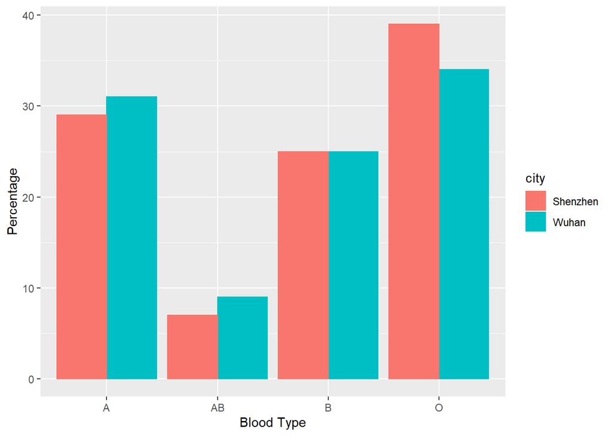

```r
p_3 = cbc19%>%
  select(city, blood, count, group)%>%
  filter(group=="Control")%>%
  group_by(city)%>%
  mutate(n=sum(count))%>%
  ungroup()%>%
  group_by(city, blood)%>%
  mutate(nBlood = sum(count),
         pctBlood = round((nBlood/n)*100))%>%
  ungroup()%>%
  select(city, blood, pctBlood)%>%
  group_by(city, blood)
graph1 = ggplot(p_3, mapping = aes(x=blood, y = pctBlood, color = city, fill = city))+geom_col(position = "dodge")+labs(x = "Blood Type", y = "Percentage")



graph1
```

4. For each of the three hospitals, create 2 by 4 tables with the distribution of blood type as percentages for the corresponding control population and the COVID-19 patients. Are there similarities across the hospitals about which blood types have higher (or lower) relative frequencies than found in the general population?

There seem to be more people with blood type A, at least in Wuhan, who get the COVID-19.

```r
p_4_jin = cbc19%>%
  select(city, group, blood, count)%>%
  filter(city == "Wuhan", group == "Control" | group=="Jinyintan")%>%
  group_by(group)%>%
  mutate(n=sum(count))%>%
  ungroup()%>%
  select(group, blood, count, n)%>%
  group_by(group, blood)%>%
  mutate(pctBlood = round((count/n)*100))%>%
  ungroup()%>%
  select(blood, pctBlood, group)%>%
  group_by(blood, group)%>%
  pivot_wider(names_from = blood, values_from = pctBlood)

p_4_ren = cbc19%>%
  select(city, group, blood, count)%>%
  filter(city == "Wuhan", group == "Control" | group=="Renmin")%>%
  group_by(group)%>%
  mutate(n=sum(count))%>%
  ungroup()%>%
  select(group, blood, count, n)%>%
  group_by(group, blood)%>%
  mutate(pctBlood = round((count/n)*100))%>%
  ungroup()%>%
  select(blood, pctBlood, group)%>%
  group_by(blood, group)%>%
  pivot_wider(names_from = blood, values_from = pctBlood)

p_4_third = cbc19%>%
  select(city, group, blood, count)%>%
  filter(city == "Shenzhen", group == "Control" | group=="Third People's Hospital")%>%
  group_by(group)%>%
  mutate(n=sum(count))%>%
  ungroup()%>%
  select(group, blood, count, n)%>%
  group_by(group, blood)%>%
  mutate(pctBlood = round((count/n)*100))%>%
  ungroup()%>%
  select(blood, pctBlood, group)%>%
  group_by(blood, group)%>%
  pivot_wider(names_from = blood, values_from = pctBlood)

p_4_jin
```

```
## # A tibble: 2 x 5
## # Groups:   group [2]
##   group         A     B    AB     O
##   <chr>     <dbl> <dbl> <dbl> <dbl>
## 1 Control      31    25     9    34
## 2 Jinyintan    38    26    10    26
```

```r
p_4_ren
```

```
## # A tibble: 2 x 5
## # Groups:   group [2]
##   group       A     B    AB     O
##   <chr>   <dbl> <dbl> <dbl> <dbl>
## 1 Control    31    25     9    34
## 2 Renmin     40    22    13    25
```

```r
p_4_third
```

```
## # A tibble: 2 x 5
## # Groups:   group [2]
##   group                       A     B    AB     O
##   <chr>                   <dbl> <dbl> <dbl> <dbl>
## 1 Control                    29    25     7    39
## 2 Third People's Hospital    29    29    14    28
```

5. For each of the three hospitals, create 2 by 4 tables of counts for controls and COVID-19 patients and conduct a chi-square test of independence. Which hospitals show evidence of a relationship between blood type and risk of COVID-19 infection?

```r
p_5_jin = cbc19%>%
  select(city, group, blood, count)%>%
  filter(city == "Wuhan", group == "Control" | group=="Jinyintan")%>%
  select(blood, count, group)%>%
  group_by(blood, group)%>%
  pivot_wider(names_from = blood, values_from = count)%>%
  ungroup()%>%
  select(A,B,AB,O)

p_5_ren = cbc19%>%
  select(city, group, blood, count)%>%
  filter(city == "Wuhan", group == "Control" | group=="Renmin")%>%
  select(blood, count, group)%>%
  group_by(blood, group)%>%
  pivot_wider(names_from = blood, values_from = count)%>%
  ungroup()%>%
  select(A,B,AB,O)

p_5_third = cbc19%>%
  select(city, group, blood, count)%>%
  filter(city == "Shenzhen", group == "Control" | group=="Third People's Hospital")%>%
  select(blood, count, group)%>%
  group_by(blood, group)%>%
  pivot_wider(names_from = blood, values_from = count)%>%
  ungroup()%>%
  select(A,B,AB,O)

chisq.test(p_5_jin)
```

```
##
##  Pearson's Chi-squared test
##
## data:  p_5_jin
## X-squared = 46.762, df = 3, p-value = 3.905e-10
```

```r
chisq.test(p_5_ren)
```

```
##
##  Pearson's Chi-squared test
##
## data:  p_5_ren
## X-squared = 8.1891, df = 3, p-value = 0.04226
```

```r
chisq.test(p_5_third)
```

```
##
##  Pearson's Chi-squared test
##
## data:  p_5_third
## X-squared = 24.983, df = 3, p-value = 1.556e-05
```

6. Create a graph that effectively displays the differences between distributions of blood type percentages in CORVID-19 patients and their controls.

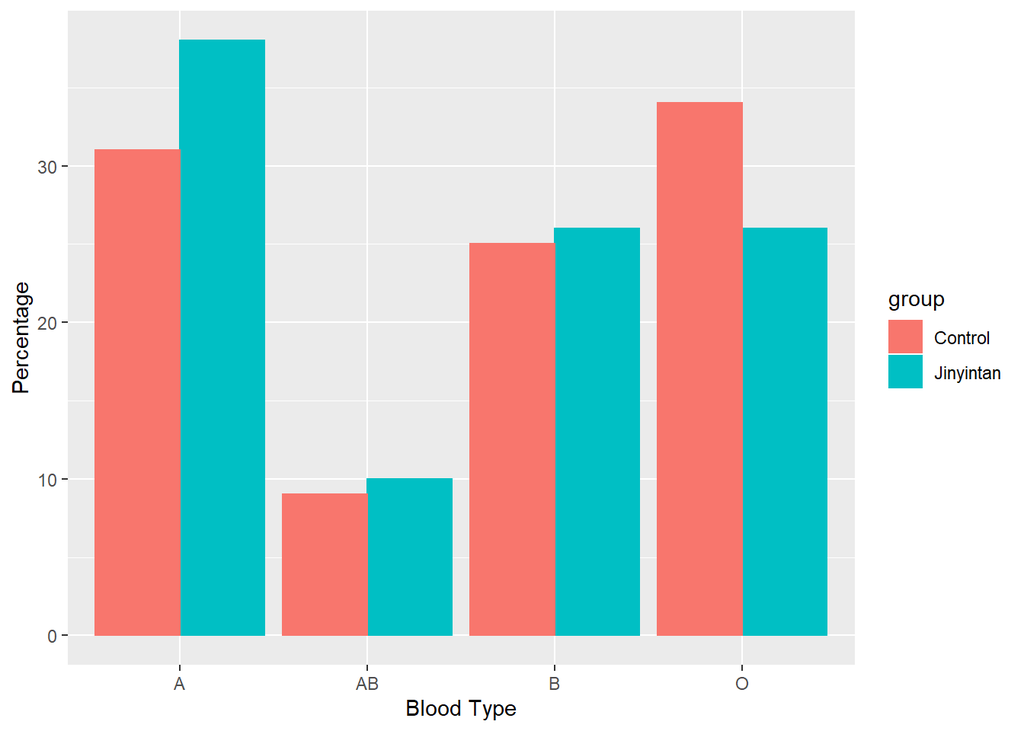

```r
p_6_jin = cbc19%>%
  select(city, group, blood, count)%>%
  filter(city == "Wuhan", group == "Control" | group=="Jinyintan")%>%
  group_by(group)%>%
  mutate(n=sum(count))%>%
  ungroup()%>%
  select(group, blood, count, n)%>%
  group_by(group, blood)%>%
  mutate(pctBlood = round((count/n)*100))%>%
  ungroup()%>%
  select(blood, pctBlood, group)%>%
  group_by(blood, group)

graph_jin = ggplot(p_6_jin, mapping = aes(x=blood, y = pctBlood, color = group, fill = group))+geom_col(position = "dodge")+labs(x = "Blood Type", y = "Percentage")

p_6_ren = cbc19%>%
  select(city, group, blood, count)%>%
  filter(city == "Wuhan", group == "Control" | group=="Renmin")%>%
  group_by(group)%>%
  mutate(n=sum(count))%>%
  ungroup()%>%
  select(group, blood, count, n)%>%
  group_by(group, blood)%>%
  mutate(pctBlood = round((count/n)*100))%>%
  ungroup()%>%
  select(blood, pctBlood, group)%>%
  group_by(blood, group)

graph_ren = ggplot(p_6_ren, mapping = aes(x=blood, y = pctBlood, color = group, fill = group))+geom_col(position = "dodge")+labs(x = "Blood Type", y = "Percentage")

p_6_third = cbc19%>%
  select(city, group, blood, count)%>%
  filter(city == "Shenzhen", group == "Control" | group=="Third People's Hospital")%>%
  group_by(group)%>%
  mutate(n=sum(count))%>%
  ungroup()%>%
  select(group, blood, count, n)%>%
  group_by(group, blood)%>%
  mutate(pctBlood = round((count/n)*100))%>%
  ungroup()%>%
  select(blood, pctBlood, group)%>%
  group_by(blood, group)

graph_third = ggplot(p_6_third, mapping = aes(x=blood, y = pctBlood, color = group, fill = group))+geom_col(position = "dodge")+labs(x = "Blood Type", y = "Percentage")


graph_jin
```

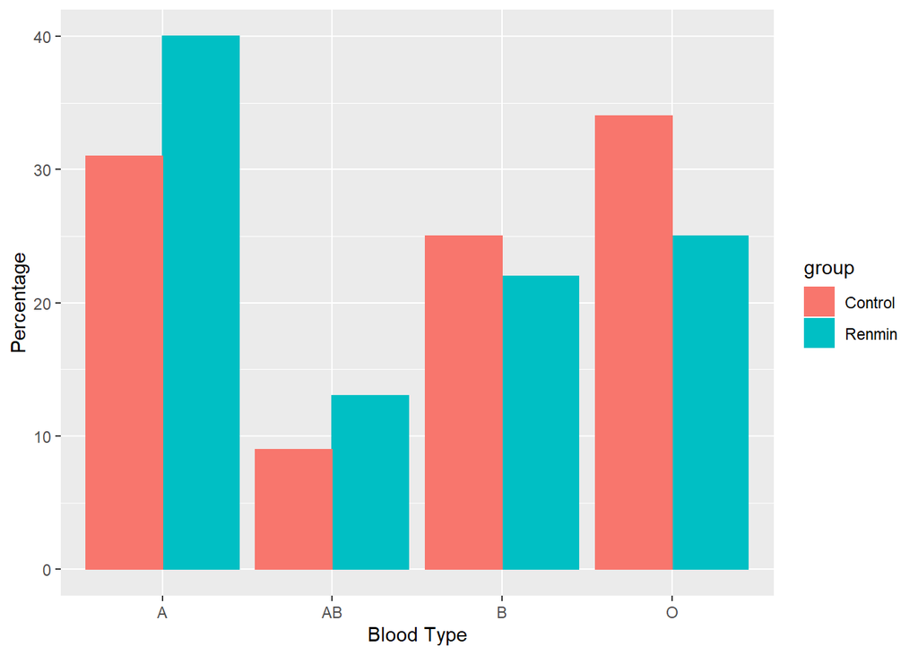

```r
graph_ren
```

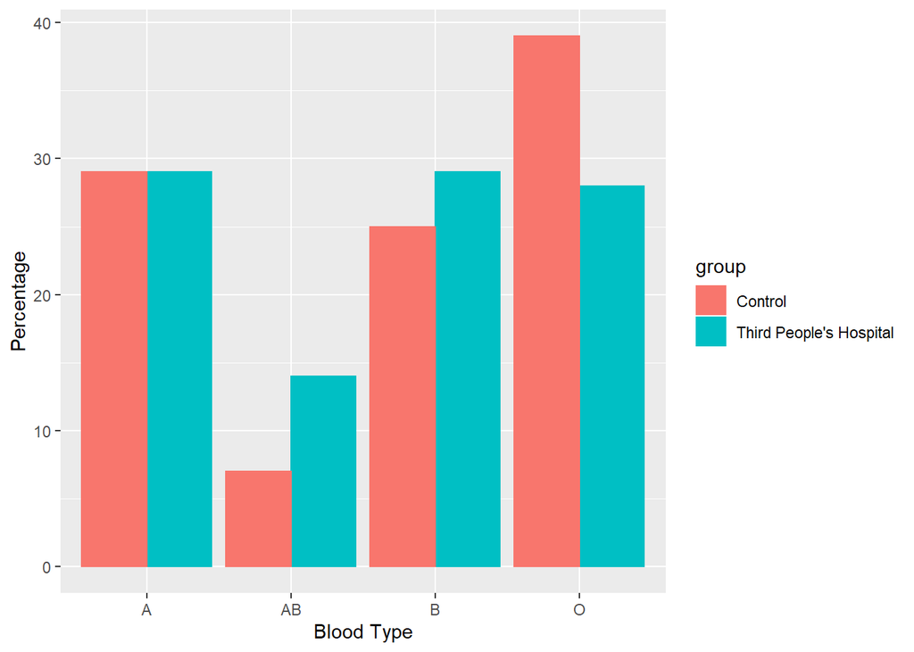

```r
graph_third
```